# Guía de R Markdown

Diplomado en Data Science UC

Junio 2019

# Mi primer documento con R Markdown

**R Markdown** es una herramienta que permite generar documentos dinámicos con **R**. Un documento de R Markdown está escrito en markdown (un formato de texto plano fácil de escribir) y contiene fragmentos de código R incrustado, como esta guía.

Para más detalles ver http://rmarkdown.rstudio.com.

R Markdown fue diseñado para una reproducibilidad más sencilla, ya que tanto el código de cómputo como las narraciones están en el mismo documento, y los resultados se generan automáticamente a partir del código fuente. R Markdown admite docenas de formatos de salida estáticos y dinámicos / interactivos.

Estos informes están compuestos por dos partes:

- el fichero que genera el informe (en formato RMarkdown cuya extensión es .RMD)
- el informe generado (en Word, PDF o HTML)

Al hacer click en el botón **Knit** se generará un documento que incluye tanto el contenido como el resultado de cualquier fragmento de código R incorporado dentro del documento.

## Primeros pasos:

- Haz clic en el menú: **File - New File - R Markdown**
- Se abrirá una ventana donde puedes seleccionar el tipo de formato que quieres tener como resultado de tu archivo .Rmd.
- Selecciona el tipo de formato que quieres como salida con los botones (puedes cambiarlo después)

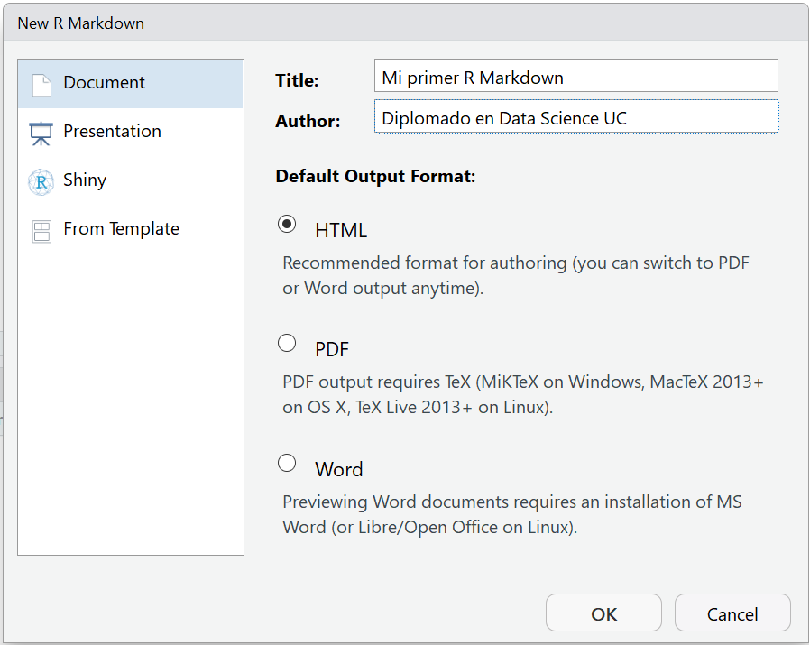

## Componentes

Hay tres componentes básicos de un documento R Markdown: los metadatos, el texto y el código.

### Metadatos

Los metadatos se escriben entre el par de tres guiones `---`. La sintaxis de los metadatos es YAML

```
    ---
    title: "Mi primer R Markdown"
    author: "Mi nombre"
    date: "2019-06-17"
    output: html_document
    ---
```

En el encabezado YAML puedes definir el tipo de documento quieres construir:

| Instrucción | Archivo |
| --- | --- |
| output: html_document | archivo html (página web) |
| output: pdf_document | archivo pdf |
| output: word_document | Microsoft Word .docx |
| output: beamer_presentation | presentación beamer (pdf) |
| output: ioslides_presentation | presentación ioslides (html) |

> Ejercicio: Compile su documento en los distintos archivos de R Markdown.

Recuerde que el método abreviado de teclado para tejer un archivo es `Ctrl + Shift + K`.

### Texto

La sintaxis del texto es Markdown:

#### Énfasis (negritas y cursivas)

```
*cursivo* y _cursivo_
**negrita** y __negrita__
superíndice^2^
~~tachado~~
```

Lo que genera:

*cursivo* y *cursivo*  
**negrita** y **negrita**  
superíndice<sup>2</sup>  
tachado

#### Encabezados

Los # se usan para crear encabezados en Markdown, debes usarlos añadiendo uno por cada nivel.

```
# Encabezado 1
## Encabezado 2
### Encabezado 3
#### Encabezado 4
##### Encabezado 5
###### Encabezado 6
```

` Lo que genera:

# Encabezado 1

## Encabezado 2

### Encabezado 3

#### Encabezado 4

##### Encabezado 5

###### Encabezado 6

#### Párrafos y saltos de línea

Para generar un nuevo párrafo en Markdown simplemente separa el texto mediante una línea en blanco (pulsando dos veces intro).

Para realizar un salto de línea y empezar una frase en una línea siguiente dentro del mismo párrafo, tendrás que pulsar dos veces la barra espaciadora antes de pulsar una vez intro.

#### Citas

```
> cita en bloque
```

> cita en bloque

#### Listas

Listas sin orden:

```
* elemento 1
* elemento 1
```

- elemento 1
- elemento 1

```
+ sub-elemento 1
+ sub-elemento 2
```

- sub-elemento 1
- sub-elemento 2

Listas ordenadas:

```
1. elemento 2
2. elemento 2
```

1. elemento 2
2. elemento 2

#### Tablas

```
 Encabezado 1 Tabla |  Encabezado 2 Tabla
 ------------------ | -------------------
 Celda 1 | Celda 2
 Celda 3 | Celda 4
```

| Encabezado 1 Tabla | Encabezado 2 Tabla |
| --- | --- |
| Celda 1 | Celda 2 |
| Celda 3 | Celda 4 |

#### Referencias

```
[link](www.rstudio.com)
```

link

#### Expresiones matemáticas

Markdown ha heredado el potencial de LATEX para generar formulas con una tipografía adecuada y elegante.

```
$f(k) = {n \choose k} p^{k} (1-p)^{n-k}$
```

Lo que resulta:

$f(k) = {n \choose k} p^{k} (1-p)^{n-k}$

#### Reglas horizontales

Las reglas horizontales se utilizan para separar secciones de una manera visual, para crearlas, en una línea en blanco deberás incluir tres de los siguientes elementos: `*`, `-` o `_`.

```
* * *
- - -
_ _ _
```

### Código:

Puedes insertar código R (chunk) usando la barra de herramientas RStudio (el botón Insertar) o con las teclas `Ctrl + Alt + I`.

##### Fragmentos de código

Comienza un fragmento con ```{r} y terminalo con ```

```r
library(knitr)
x=rnorm(100)
mean(x)
```

```
## [1] -0.05335862
```

##### Código incrustado

R reemplaza el codigo en la línea con sus resultados:

El promedio de la muestra es ` r mean(x) `.

El promedio de la muestra es -0.0533586.

## Ejercicio

El tiempo medio de funcionamiento de cierto aparato electrónico distribuye exponencial con una media de 100 días.

1. Simule una población de tamaño 50.000 con dicha distribución.
   - Calcule el promedio de su población
   - Construya un histograma de su población.
2. Simule 10.000 muestras de tamaño 5 de su población.
   - calcule el promedio de cada muestra.
   - Construya un histograma de los promedios de la muestra.
3. Simule 10.000 muestras de tamaño 100 de su población.
   - Calcule el promedio de cada muestra.
   - Construya un histograma de los promedios de la muestra.